GCxGC/MS Rocket Fuel Project -- Joe, Esmeralda, Wan-chen, Andy

# Background.

Gas chromatography (GC) is a chemical separation technique that has been in use for several decades. In GC, volatile analytes are passed through a column at elevated temperatures using a carrier gas. The molecules of volatile compounds interact with the lining of the GC column, known as the stationary phase. Different analytes have different affinities for the stationary phase, and therefore will pass through the column at different rates. This allows several compounds present in a sample to be separated in time and individually detected and quantified.

One problem that can arise with conventional GC is that when analyzing complex samples, it is possible that multiple compounds can have the same affinity for the stationary phase of the GC column, and therefore elute at the same time. Orthogonal methods, such as mass spectrometry (MS) have been developed to detect multiple compounds at the same time. In mass spectrometry, the analytes coming from the GC column are broken apart and ionized by electron collision. These ion fragments are moved by a voltage. Kinetic energy of heavy and light ion fragments - 1/2 mv^2 - is held constant, and therefore the ions are separated in time based on their velocities.

These separation methods have been combined in systems known as gas chromatography-mass spectrometers (GCMS). These instruments have been used for a wide variety of applications. However, there are still limitations in analyte separation. For these reasons, two-dimensional GC (GCxGC) has been developed.

GCxGC involves passing an analyte through two columns, each with a different stationary phase type and separated by a modulator. Column 1 is a more polar column lined with diphenylpolysiloxane, while column two contains dimethylpolysiloxane. In this way, compounds which have a similar affinity for the phase on column 1 may have different affinity for the phase on column 2 and be separated. This difference in separation capability can be seen in the data of rocket fuel shown below. The large, curved red band on the upper half of the chromatogram indicates non-polar alkanes and cyclic alkanes, which are separated from the band of more polar aromatic compounds located in the lower half of the chromatogram.

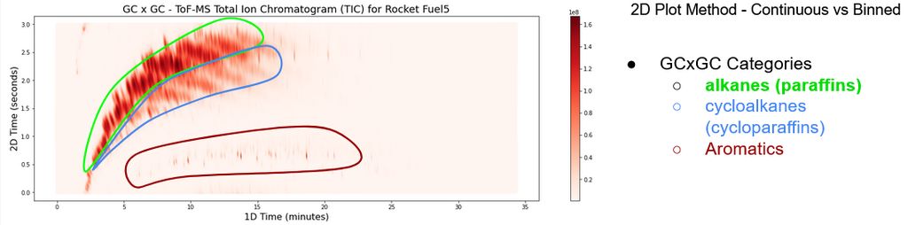

This GCxGC data has been used by Kelsey Berrier et. al. in the Synovec group at UW to perform partial least squares analysis on the physical properties of various rocket fuels (1). In their analysis, they apply partial least squares (PLS) analysis on a dataset containing GCxGC/MS data from 74 fuel samples. They break this dataset into to 66 training and 8 testing samples, then correlate GCxGC/MS data to the physical properties observed in these fuels and predict properties of test samples which are cross-validated. Using PLS analysis, the researchers obtained normalized root-mean-squared error of around 10% for many physical properties for these fuels.

Our motivation behind this project is to demonstrate if it is possible to observe similar correlations between GCxGC/MS data using an artificial neural network (ANN). After discussion with researchers in the Synovec group, they gave the opinion that an artificial neural network would likely require many hundreds of samples to provide a robust enough training dataset. Our goal is to develop an ANN and document all successes as well as challenges with using a neural network to train and cross-validate a dataset which is believed to be too small for use.

In this work we perform data processing, imaging and manipulation on 30 rocket fuels. We also create an ANN to correlate this processed GCxGC/MS data with physical properties. In addition, we create a second ANN using a compressed dataset containing 72 rocket fuel samples present in the paper. We contrast results between dataset sizes and discuss possible sources of error for the ANN.

A similar research paper by Liu et. al., which performed ANN analysis of one-dimensional GC/MS data contained a dataset of 80 fuel samples, and achieved correlation coefficients of 0.5 to 0.9 for various physical properties (2). Though their dataset is not in use in our project, we use their results as our performance benchmark.

```python
# Connect our files in google drive to the notebook and create an associated
# file path
from google.colab import drive
drive.mount('/content/drive')
file_path = '/content/drive/MyDrive/Fuels_Data/'
```

```python
import numpy as np
import scipy.io as sp
import pandas as pd
import matplotlib.pyplot as plt
import h5py
from mpl_toolkits import mplot3d

import plotly.express as px
import matplotlib.ticker as mtick

from tensorflow import keras
from tensorflow.keras.models import Sequential
from tensorflow.keras.layers import Dense
from tensorflow.keras.layers import Dropout
from tensorflow.keras.wrappers.scikit_learn import KerasRegressor
from tensorflow.keras.wrappers.scikit_learn import KerasClassifier
from tensorflow.keras import Input

from sklearn.model_selection import train_test_split
from sklearn.preprocessing import StandardScaler
from sklearn.preprocessing import QuantileTransformer
from sklearn.pipeline import Pipeline
from sklearn.preprocessing import LabelEncoder
from sklearn.preprocessing import LabelBinarizer
from sklearn.model_selection import RandomizedSearchCV
from sklearn.metrics import r2_score

#Dataframe containing all physical properties of various rocket fuels
all_properties = pd.read_csv(file_path + 'PropertiesTable.csv')
print(all_properties.head())
```

```
   Sample Number    Sample Name  ... Density @ 45C (g/mL)  Density @ 85C (g/mL)
0              1     YA2921HW10  ...              0.78841               0.75906
1              2     BG1121GP04  ...              0.78714               0.75797
2              3  GRC/0-100 HEP  ...              0.78801               0.75861
3              4     WC0721HW01  ...              0.78149               0.75241
4              5    LB073009-05  ...              0.79184               0.76259

[5 rows x 9 columns]
```

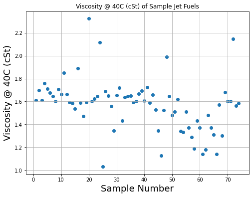

```python
#Plot the actual trend of Viscosity across various fuel samples (https://doi.org/10.1021/acs.energyfuels.9b04108)
plt.figure(figsize=(8,6))

plt.scatter(all_properties['Sample Number'], all_properties['Viscosity @ 40C (cSt)'])
plt.xlabel("Sample Number", fontsize = 18)
plt.ylabel("Viscosity @ 40C (cSt)", fontsize = 18)
plt.title("Viscosity @ 40C (cSt) of Sample Jet Fuels")
plt.grid()
```

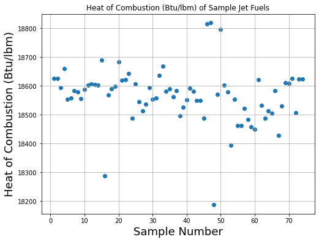

```python
#Plot the actual trend of heat of combustion across various fuel samples (https://doi.org/10.1021/acs.energyfuels.9b04108)
plt.figure(figsize=(8,6))

plt.scatter(all_properties['Sample Number'], all_properties['Heat of Combustion (Btu/lbm)'])
plt.xlabel("Sample Number", fontsize = 18)
plt.ylabel("Heat of Combustion (Btu/lbm)", fontsize = 18)
plt.title("Heat of Combustion (Btu/lbm) of Sample Jet Fuels")
plt.grid()
```

```
(290, 206011)
```

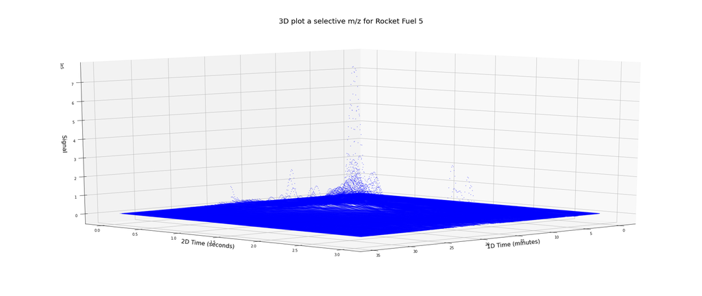

```python
#Loading Fuel5 Data for Visualization of m/z 91, an ion indicative of aromatic compounds.

f = h5py.File(file_path + 'Fuel5.mat', 'r')
arrays = {}
for k, v in f.items():
    arrays[k] = np.array(v)
    Fuel5_signal = pd.DataFrame(arrays[k])

#there are 290 m/z channels and 206011 scans per channel. 205800 scans (x-axis); 686 modulations (y-axis)
print(Fuel5_signal.shape)
Fuel5_signal = Fuel5_signal.transpose()
#There is an incomplete 687th modulation; this is chopped off.
Fuel5_signal = Fuel5_signal.drop(Fuel5_signal.index[205200:206011])

# The length of all fuel data will be exactly the same.
Fuel_length = np.linspace(0,len(Fuel5_signal),len(Fuel5_signal))

#3D Plot of one m/z Channel
plt.figure(figsize=(35, 15))
ax = plt.axes(projection = '3d')
ax = plt.axes(projection='3d')

'''
Fuel_length/6000 - Fuel_length/300, the modulation number of the run, converted into Fuel_length/6000, minutes.
(3sec/modulation)
(Fuel_length%300)/100 - Fuel_length%300, the scans within a single modulation,
converted into (Fuel_length%300)/100 seconds. (300 scans/sec)
Fuel5_signal[91] the abundance of mass channel m/z 91, for the entire run.
'''
plot1=ax.scatter3D(Fuel_length/6000, (Fuel_length%300)/100, Fuel5_signal[91], s=1, c='blue',
                   label='original', alpha = 0.4)
ax.view_init(10, 45)
plt.title('3D plot a selective m/z for Rocket Fuel 5', fontsize = 20)
plt.xlabel('1D Time (minutes)', fontsize = 16)
plt.ylabel('2D Time (seconds)', fontsize = 16)
ax.set_zlabel('Signal', fontsize = 16)
plt.ticklabel_format(axis="z", style="sci", scilimits=(0,0));
```

**Equation Justification for plt.scatter function below**

xy+90 - There is a modulation offset. This is applied to improve visual effect. The chemical basis for this is, although a modulation occurs once every 3 sec, certain compounds require more than 3 sec to travel down the column. In GCxGC, this is expected phenomena, however a visualization artifact remains where part of the chromatogram appears "cut off." The solution to prevent cutoff is to increase the modulation time (for example, 4 sec), but this costs compound resolution and was not performed. Therefore, to provide a pleasing visual we create an artificial offset.

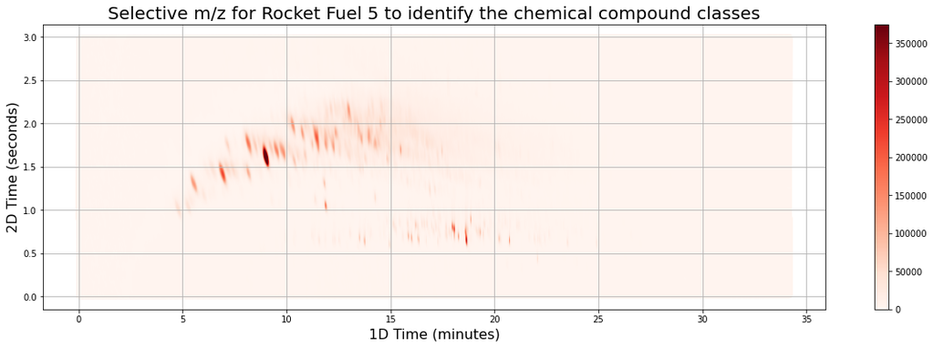

```python
#Scatter Plot of m/z channel 91. This 2D visualization is easier to understand at a glance and is
# used over 3D for this report.

plt.figure(figsize=(20, 6))
#m/z 91 is a common peak for aromatic compound breakdown.
plt.scatter(Fuel_length/6000, ((Fuel_length+90)%300)/100, c=Fuel5_signal[91], cmap = 'Reds')

plt.grid(b=None)
plt.title('Selective m/z for Rocket Fuel 5 to identify the chemical compound classes', fontsize = 20)
plt.xlabel('1D Time (minutes)', fontsize = 16)
plt.ylabel('2D Time (seconds)', fontsize = 16)
plt.clim(0,Fuel5_signal[91].max()/2) #The maximum colorbar is reduced to increase sensitivity of graph
plt.colorbar();
```

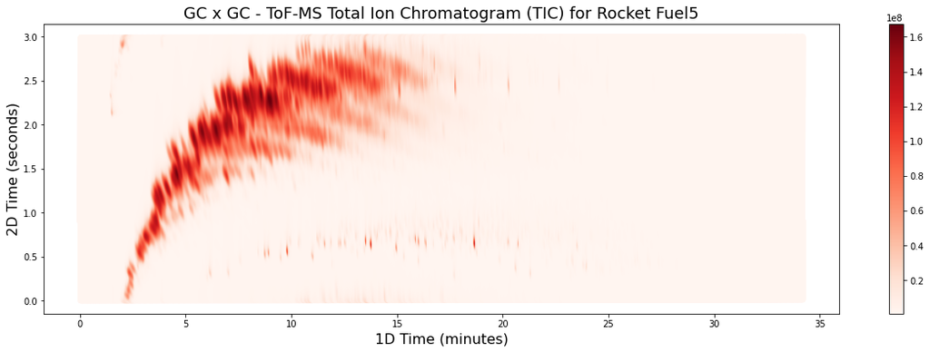

```python
#Scatter Plot of summed m/z channels
Fuel5_signal_sum = Fuel5_signal.transpose().sum()
plt.figure(figsize=(20, 6))
#Fuel_length+90 - There is a modulation offset. This is applied to improve visual effect.
plt.scatter(Fuel_length/6000, ((Fuel_length+90)%300)/100,c=Fuel5_signal_sum, cmap='Reds')
plt.title("GC x GC - ToF-MS Total Ion Chromatogram (TIC) for Rocket Fuel5", fontsize = 18)
plt.xlabel('1D Time (minutes)', fontsize = 16)
plt.ylabel('2D Time (seconds)', fontsize = 16)
plt.colorbar();
```

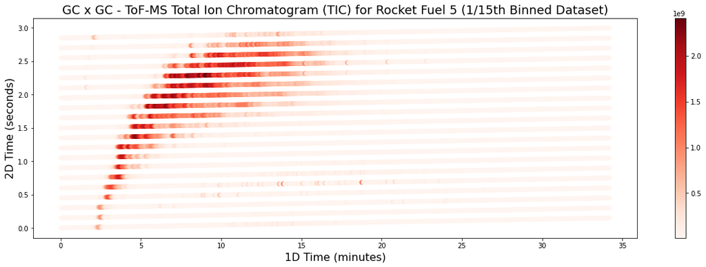

```python
BIN = 15
#Every 15 data points sill be summed and combined into one data point.
Fuel5_bin = Fuel5_signal.groupby(Fuel5_signal.index // BIN).sum()

Fuel_length_bin = np.linspace(0,int(len(Fuel5_signal))/BIN,int(len(Fuel5_signal)/BIN))
Fuel5_bin_sum = Fuel5_bin.transpose().sum()

plt.figure(figsize=(20, 6))
#This modulation offset formula is continued as in previous versions.
plt.scatter(Fuel_length_bin/(6000/BIN), (((Fuel_length_bin+(90/BIN)))%(300/BIN)/(100/BIN)),c=Fuel5_bin_sum, cmap='Reds')
ax.grid(False)

plt.title("GC x GC - ToF-MS Total Ion Chromatogram (TIC) for Rocket Fuel 5 (1/"+str(BIN)+"th Binned Dataset)", fontsize = 18)
plt.xlabel('1D Time (minutes)', fontsize = 16)
plt.ylabel('2D Time (seconds)', fontsize = 16)
plt.colorbar();
```

A different binning technique was devised in order to preserve correct aspect ratio of binned datapoints. In the above example, only the 2D GC dimension was binned properly. We require both dimensions to be binned. The bin size is such that approximately one analyte will fit within one binned pixel. Any lower bin size, and there is a great risk of splicing peaks in between bins. Any greater bin size, and there is a loss of chemical information due to peak mixing.

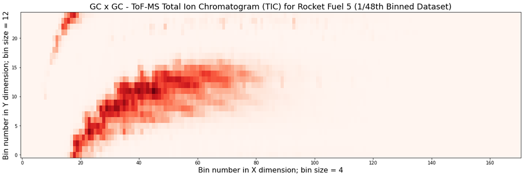

```python
xbin = 4
ybin = 12
Fuel5_signal_bin = Fuel5_signal_sum.to_numpy()
#This function reshapes XY space to 171x25.
Fuel5_signal_bin = np.reshape(Fuel5_signal_bin,(int(684/xbin),xbin,int(300/ybin),ybin))
#The xbin dimension of size 4 is summed into the 171-length X dimension.
Fuel5_signal_bin = np.sum(Fuel5_signal_bin, axis = 1)
#The ybin dimension of size 12 is summed into the 25 length Y dimension.
Fuel5_signal_bin = np.sum(Fuel5_signal_bin, axis = 2)

x = np.arange(-0.5,684/xbin,1)
y = np.arange(-0.5,300/ybin,1)

fig, ax = plt.subplots(figsize = (20,6))
#Below, you can observe the effect of not applying modulation offset.
#The light alkane tail is cut off. This will be resolved in the next section.
ax.pcolormesh(x,y,Fuel5_signal_bin.transpose(), cmap = 'Reds')
ax.set_xlabel("Bin number in X dimension; bin size = " + str(xbin), fontsize = 16)
ax.set_ylabel("Bin number in Y dimension; bin size = " + str(ybin), fontsize = 16)
ax.set_title("GC x GC - ToF-MS Total Ion Chromatogram (TIC) for Rocket Fuel 5 (1/"+str(xbin * ybin)+"th Binned Dataset)", fontsize = 18)

Fuel5_1d = np.reshape(Fuel5_signal_bin, -1)
```

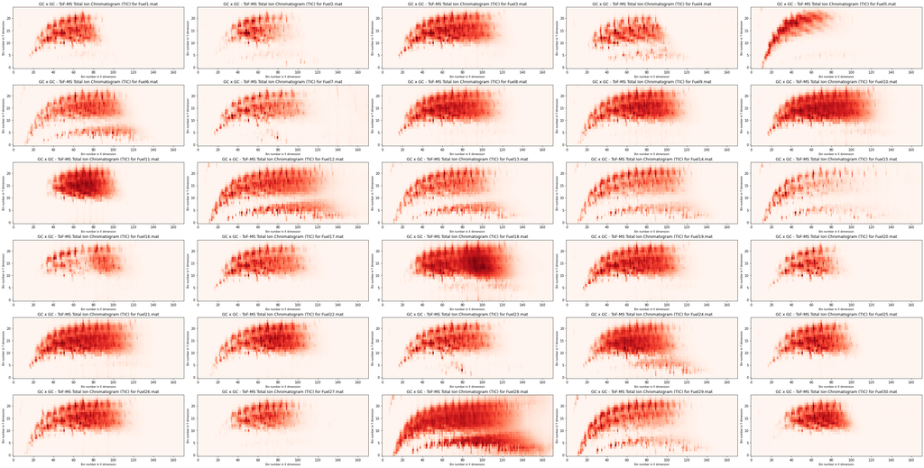

```python
#Data import, reregistry, preprocessing and visualization of 30 fuels - raw datasets.
# These fuel numbers do NOT correspond to the order given in the paper.

#Here we simply take the portion of code above and define it as a function.
def reshape_bin_data(xbin, ybin, dataset):
    reshaped = dataset.to_numpy()
    reshaped = np.reshape(reshaped,(int(684/xbin),xbin,int(300/ybin),ybin))
    reshaped = np.sum(reshaped, axis = 1)
    reshaped = np.sum(reshaped, axis = 2)
    return reshaped

file_test = ['Fuel1.mat', 'Fuel2.mat', 'Fuel3.mat', 'Fuel4.mat', 'Fuel5.mat', 'Fuel6.mat', 'Fuel7.mat', 'Fuel8.mat',
            'Fuel9.mat', 'Fuel10.mat', 'Fuel11.mat', 'Fuel12.mat', 'Fuel13.mat', 'Fuel14.mat', 'Fuel15.mat', 'Fuel16.mat',
             'Fuel17.mat', 'Fuel18.mat', 'Fuel19.mat', 'Fuel20.mat', 'Fuel21.mat', 'Fuel22.mat', 'Fuel23.mat', 'Fuel24.mat',
              'Fuel25.mat', 'Fuel26.mat', 'Fuel27.mat', 'Fuel28.mat', 'Fuel29.mat', 'Fuel30.mat']

ml_properties = pd.read_csv(file_path + 'MLProperties.csv')

sum_features = []
sum_bin = []
features_91= []
bin_91 = []
xbin = 4
ybin = 12
n = 0

fig, ax = plt.subplots(6,5, sharex=False, sharey=False, figsize = (40,20))
fig.subplots_adjust(hspace = 0.5)
fig.tight_layout(h_pad = 3) #This simply improves the visual layout

#creates a features array (3x1) which contains the dfsum of the three files chosen above
for fuel in file_test:
    f = h5py.File(file_path + fuel, 'r')
    arrays = {}
    for k, v in f.items():
        arrays[k] = np.array(v)
        df = pd.DataFrame(arrays[k])
    df = df.transpose()
    #Here, instead of applying an offset of 90 to the final graph, the offset is applied when retrieving the data.
    #(Here, the offset is 85)
    df = df.drop(df.index[205415:])
    df = df.drop(df.index[0:215])
    dfsum = df.transpose().sum()
    #Calling the function above, using xbin and ybin specified previously.
    dfsum = reshape_bin_data(xbin,ybin,dfsum)

    x = np.arange(-0.5,684/xbin,1)
    y = np.arange(-0.5,300/ybin,1)

    #This is a way of plotting different subplots.
    ax[int(n/5),n%5].pcolormesh(x,y,dfsum.transpose(), cmap = 'Reds')
    ax[int(n/5),n%5].set_xlabel("Bin number in X dimension", fontsize = 8)
    ax[int(n/5),n%5].set_ylabel("Bin number in Y dimension", fontsize = 8)
    ax[int(n/5),n%5].set_title("GC x GC - ToF-MS Total Ion Chromatogram (TIC) for " + str(fuel), fontsize = 12)

    #The data used to create the 2D plot is reshaped to a 1D array and passed to sum_bin - this is what was
    # used for data processing prior to obtaining a full dataset of 72 pre-binned fuel samples.
    dfsum = np.reshape(dfsum, -1)
    sum_bin.append(dfsum)
    n = n+1
```

```
(900000, 78)
```

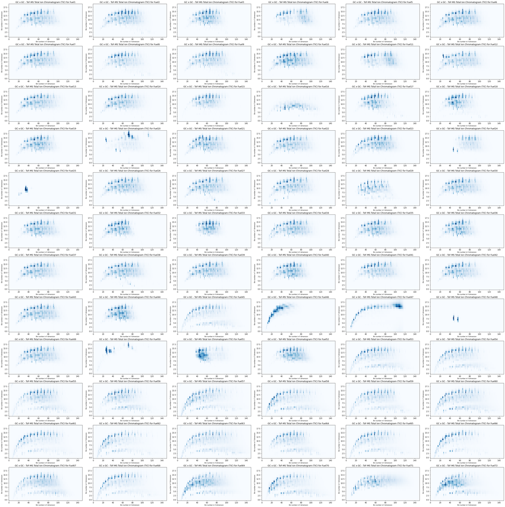

```python
#Code for GCxGC/MS data import, reshaping and visualization of pre-binned dataset.
#These fuel numbers DO correspond to the order given in the paper.

#Data received 12/09/21 containing full set of 74 samples already binned.
arraysfull = {}

g = h5py.File(file_path + 'Data_74samples.mat', 'r')
for k, v in g.items():
    #There are other dictionaries in this .mat file containing other information.
    #The GCxGC/MS data is contained in Data1.
    if(k == 'Data1'):
        arraysfull[k] = np.array(v)
        Full_signal = pd.DataFrame(arraysfull[k])
#There are 78 fuels with 900000 pre-binned datapoints. Fuels 73-78 do not contain offset correction.
#Since this data was collected in 2019/2020 and the researcher has graduated, we cannot assume how the
#alignment of data was performed. So, Fuels 73-78 are discarded from the dataset.
print(Full_signal.shape)
full_sum = Full_signal.transpose().sum()
full_list = []

fig, ax = plt.subplots(12,6, sharex=False, sharey=False, figsize = (40,40))
fig.subplots_adjust(hspace = 0.5)
fig.tight_layout(h_pad = 3, w_pad = 3)

for n in range (0,72):
    full_sum = Full_signal[n]
    full_sum = full_sum.to_numpy()
    #The 900000 data points are organized:
    #300 mass channels
    #for each mass channel, 4500 points, 150 along GC1 and 20 along GC2.
    full_sum = np.reshape(full_sum, (300,150,20))
    #Due to computational constraints, not all mass channels can be analyzed
    #this axis is summed and dimensionality of data reduced.
    full_sum = full_sum.sum(axis = 0)

    x = np.arange(-0.5,150,1)
    y = np.arange(-0.5,20,1)

    ax[int(n/6),n%6].pcolormesh(x,y,full_sum.transpose(), cmap = 'Blues')
    ax[int(n/6),n%6].set_xlabel("Bin number in X dimension", fontsize = 8)
    ax[int(n/6),n%6].set_ylabel("Bin number in Y dimension", fontsize = 8)
    ax[int(n/6),n%6].set_title("GC x GC - ToF-MS Total Ion Chromatogram (TIC) for Fuel" + str(n+1), fontsize = 12)

    #For processing into NN, the data is reshaped into one-dimensional vector.
    full_sum = np.reshape(full_sum, -1)
    #full_list contains 72 vectors. Each contains the binned TIC data for one rocket fuel.
    full_list.append(full_sum)
```

# Methods

Rocket fuels contain a mixture of a large number of compounds, from linear and branched alkanes, to cyclic alkanes, aromatic compounds, as well as fuel stabilizers and oxygenates. In an ideal chemical solution where there are no perturbative effects caused by mixing, it is assumed that the physical properties of a mixture can be expressed as a linear combination of the physical properties of all components of that mixture. Due to this assumption, it follows that a method such as partial least squares analysis or some other form of multilinear regression is a prime candidate for this task.

However, it is also possible that mixtures of compounds may not behave ideally. There are phenomena in chemistry that support this: for example, the formation of azeotropic mixtures whose boiling points cannot be determined from the linear combinations of the components. In the same vein, it is possible that certain interactions between components in a rocket fuel may cause changes in physical properties which cannot be explained by a simple linear regression model. In this case, it behooves us to attempt a different model which can explain these factors. The artificial neural network is therefore the method we chose for our dataset.

The neural network is composed of an input layer, hidden layers, and an output layer. These layers contain a network of interconnected nodes called neurons. Before feeding our data into the network, it is important to rescale our data as input values to neural networks are typically close to zero. The node of a neural network has an activation function that defines the output and can be generally classified as ridge, radial, or folding activation functions. The purpose of the activation function is to decide whether or not a node should be activated. This is acheived by calculating a weighted sum of the inputs and adding a bias. The type of activation function used is determined based on the neural network architecture. For our purposes, the most appropriate activation functions were the GeLU and Tanh functions. Our reasoning for choosing these activation functions and additional parameters used in our neural network model can be found in our notebook annotations.

## Neural Network Tuning

### Dense 1

With GeLU or ReLU activation functions, negative values are essentially zero; Therefore, variance of values are essentially 1/2 of expected. he_uniform initialization doubles variance of these initial weights (4). With ReLU activation function, we were experiencing a high amount of cases where the final predicted values would be zero. After researching the topic, this is called "Dying ReLU problem" and to avoid this we impart a non-zero activation function below z-score 0, called GeLU (gaussian exponential linear unit).

### Dense 2

With Tanh activation functions from -1 to 1, the variance is not 1/2 of expected, so glorot_uniform initialization which does not double variance of initial weights is used. (4)

### Dense 3

We were experiencing high loss with Tanh as the final hidden layer, so we added a second GeLU layer.

### Dense 4

A uniform distribution of hidden layer 2 is chosen and passed through the function y = x; this results in a complete "pass through" of hidden layer 2.

### Compilation Method

Mean squared error and mean squared logarithmic error were both tested. Since we believe that deviation of results between samples can be more extreme, we use MSLE instead of MSE.

### Scalers

When running NN simulations, we observed that properties with more evenly distributed values, such as Viscosity (1.0 - 2.2), have improved test predictions compared to properties whose distribution was concentrated in one region and contained outliers,such as hydrogen content or densities. Therefore, we tried PowerTransformer as opposed to StandardScaler to apply an additional normalization to elements in the dataset which can overweight outliers. However, we find that this provided negligible improvement, if any, and occasionally led to NaN results. The true solution is to increase the size of the dataset and, in doing so, improve the distribution and variety of input values.

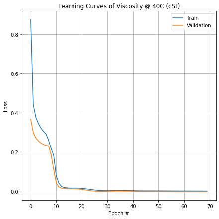

```
[1.33716   1.5642382 1.6624196 1.3775628 1.3392923 1.4582928 1.3264025
 1.6347038]
Final MSE for train is 0.00237
Final MSE for validation is 0.00008
Test set mse is 0.00142
Training Correlation Coefficient = 0.7053784177312598
```

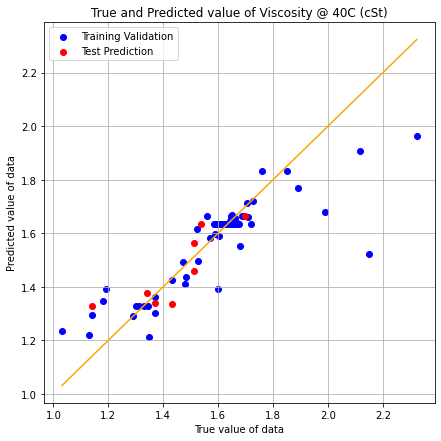

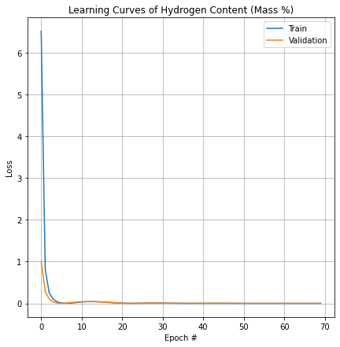

```
[14.422063 14.354973 14.018256 14.421889 14.404465 13.988129 14.137608
 14.368711]
Final MSE for train is 0.00045
Final MSE for validation is 0.00032
Test set mse is 0.00044
Training Correlation Coefficient = 0.2321828832268057
```

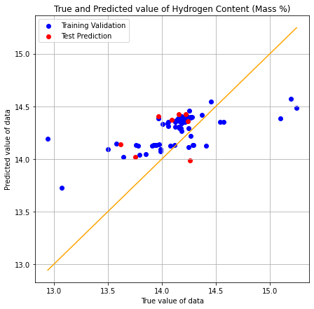

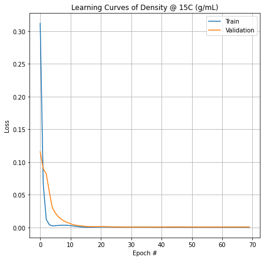

```
[0.80543983 0.8054408  0.7997806  0.80002147 0.8053271  0.8054437
 0.80594265 0.8053272 ]
Final MSE for train is 0.00009
Final MSE for validation is 0.00052
Test set mse is 0.00002
Training Correlation Coefficient = -0.3469184789065709
```

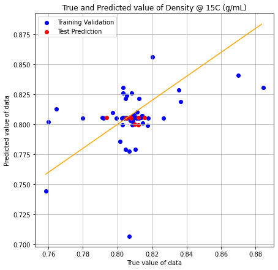

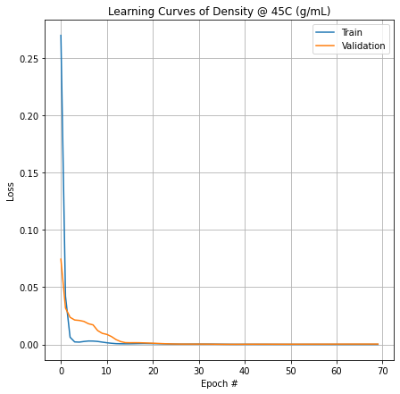

```
[0.77562076 0.8043586  0.7740819  0.78226817 0.7965594  0.7757304
 0.7945749  0.81924915]
Final MSE for train is 0.00005
Final MSE for validation is 0.00035
Test set mse is 0.00034
Training Correlation Coefficient = 0.09568450231643522
```

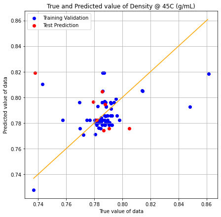

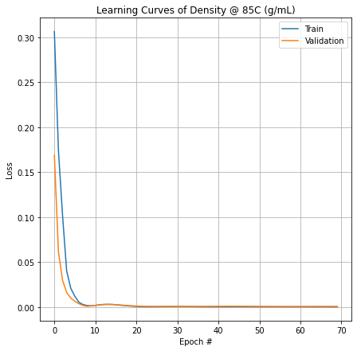

```
[0.7588129  0.78796864 0.7929971  0.80816334 0.76406634 0.7628387
 0.7615852  0.76406634]
Final MSE for train is 0.00009
Final MSE for validation is 0.00051
Test set mse is 0.00049
Training Correlation Coefficient = -0.52989520857856
```

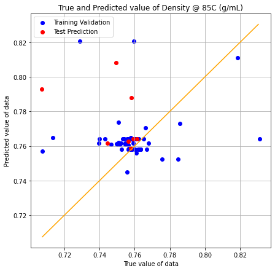

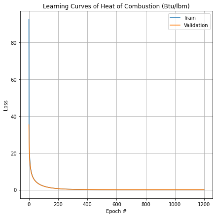

```
[18409.832 18635.54  18424.082 18635.53  18635.535 18413.316 18635.533
 18635.54 ]
Final MSE for train is 0.00004
Final MSE for validation is 0.00003
Test set mse is 0.00005
Training Correlation Coefficient = -0.2732755699845304
```

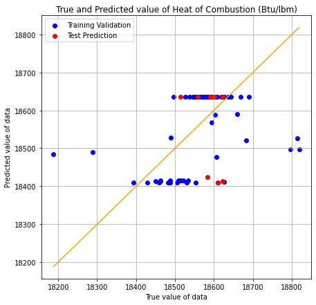

```python
# Create Neural Network
# Due to large dataset size and several properties, we did not run Keras optimization for every property.
# However, we did attempt to research and optimize the NN parameters.

#This removes fuels #73/74, the data of which was misaligned.
properties = all_properties.iloc[0:72]

#We define this function to support various hidden layers and learnings rates for each physical property.
#We have found that the GeLU-Tanh-GeLU architecture, MSLE loss and Adam optimizer generally work well.
def nn_sum_full(hLayer, learningRate):
    model = Sequential()
    #3000 data points per sample (150x20 from above) - this is the size of the input layer.
    model.add(Dense(3000, input_dim=x_train_norm74.shape[1],
                    kernel_initializer='he_uniform', activation = 'gelu'))

    model.add(Dense(hLayer, kernel_initializer='glorot_uniform', activation='tanh'))

    model.add(Dense(hLayer, kernel_initializer='he_uniform', activation='gelu'))

    model.add(Dense(1, kernel_initializer='uniform', activation='linear'))

    optimizer = keras.optimizers.Adam(learning_rate = learningRate)
    model.compile(loss='mean_squared_logarithmic_error', optimizer='Adam')
    return model

label_index = ['Viscosity @ 40C (cSt)',
               'Hydrogen Content (Mass %)',
               'Density @ 15C (g/mL)',
               'Density @ 45C (g/mL)',
               'Density @ 85C (g/mL)',
               'Heat of Combustion (Btu/lbm)']

#Settings for each physical parameter in the form (neurons in hidden layers, learning rate, epochs)
nnSettings = np.array([(70, 0.000001, 70),          #Viscosity parameters
                       (400, 0.00000002, 70),       #Hydrogen content
                       (35, 0.0000005, 70),         #15C Density
                       (35, 0.0000002, 70),         #45C Density
                       (35, 0.0000001, 70),         #85C Density
                       (3000, 0.01, 1200)])         #Heat of Combustion - This parameter performed poorly.

n = 0

for value in label_index:

  # Separate data into train and test set
  x_train74, x_test74, y_train74, y_test74 = train_test_split(full_list, properties[value],
                                                      test_size=0.1) #We train 90% of dataset and test 10% of dataset.

  scaler74 = StandardScaler().fit(x_train74)

  x_train_norm74 = scaler74.transform(x_train74)
  x_test_norm74 = scaler74.transform(x_test74)

  #nn_sum is the neural network model we defined above
  estimator74 = KerasRegressor(build_fn=nn_sum_full, hLayer = nnSettings[n,0], learningRate = nnSettings[n,1])
  history74 = estimator74.fit(x_train_norm74, y_train74, validation_split=0.1, epochs=int(nnSettings[n,2]), batch_size=66, verbose=0)


  #Plot learning Curves
  plt.figure(figsize = (7,7))
  plt.plot(range(int(nnSettings[n,2])),history74.history['loss'])
  plt.plot(range(int(nnSettings[n,2])),history74.history['val_loss'])
  plt.title('Learning Curves of ' + str(value))
  plt.ylabel('Loss')
  plt.xlabel('Epoch #')
  plt.legend(['Train', 'Validation'], loc='upper right')
  plt.grid()
  plt.show()


  y_train_predict74 = estimator74.predict(x_train_norm74)
  y_test_predict74 = estimator74.predict(x_test_norm74)
  print(y_test_predict74)

  # Plot True value on x and Predicted value on y
  plt.figure(figsize = (7,7))
  plt.scatter(y_train74, y_train_predict74, c = 'blue', label = "Training Validation")
  plt.scatter(y_test74, y_test_predict74, c = 'red',  label = "Test Prediction")
  plt.xlabel("True value of data")
  plt.ylabel("Predicted value of data")
  plt.title('True and Predicted value of ' + str(value))
  plt.plot(np.arange(min(y_train74),max(y_train74),0.001),np.arange(min(y_train74),
                                                             max(y_train74),0.001),
                                                             c='orange')
  plt.legend()
  plt.grid()

  print("Final MSE for train is %.5f" % history74.history['loss'][-1])
  print("Final MSE for validation is %.5f" % history74.history['val_loss'][-1])
  test_loss = estimator74.model.evaluate(x_test_norm74, y_test74)
  print("Test set mse is %.5f" % test_loss)
  print("Training Correlation Coefficient = " + str(r2_score(y_train74,y_train_predict74)))

  n = n+1
```

[figure not shown]

# Results/Discussion.

However, while the Viscosity model performed respectably, in general the neural network did not perform to the level of partial least squares used in the Berrier paper, nor the neural network used in the Liu paper. Here we propose possible reasons for each deficiency.

In the Berrier paper, it is noted that all linear regression vectors which were generated through partial least squares analysis were further processed using ANOVA, an featured a cutoff in order to determine which linear regression vectors had strong predictive effects on the properties of the rocket fuels. This methodology seems similar to principle component analysis, where the dimensionality of the data can be reduced while still retaining relevant differences between datasets. In contrast, system did not contain extra methods to select for highly correlative features, aside from the neural network itself.

In the Liu paper, the authors stress that the fuel dataset was selected to have a comprehensive range of values for each property. When the values of a physical property are more evenly distributed, the correlation coefficient generated by the neural network is improved. This can be observed in our work by comparing our Viscosity training, which contained a distributed dataset, to other fuel properties whose distribution of values was more concentrated. In general, the correlation coefficient of our Viscosity training was around 0.7-0.8; for hydrogen content, around 0.2-0.4, and for densities and heat of combustion, generally uncorrelated.

In short, what we can do in the future is:

1. Inclusion of more rocket fuels with more evenly distributed physical values in dataset to get more comprehensive training
2. Removal of outliers and re-training data to yield a lower error to get more specific training
3. To make training more specific to compounds detected in the fuel, We can train all m/z channels (input layer = 900,000), not just the sum of the m/z channels (input layer = 3,000) with high performance computing, which we were not able to utilize in this project.

We hope that this work has provided a place of entry for the analysis of complex GCxGC/MS datasets by neural networks.

# Citations

(1) Berrier, Kelsey L., Chris E. Freye, Matthew C. Billingsley, and Robert E. Synovec. "Predictive modeling of aerospace fuel properties using comprehensive two-dimensional gas chromatography with time-of-flight mass spectrometry and partial least squares analysis." Energy & Fuels 34, no. 4 (2020): 4084-4094.

(2) Liu, Guozhu, Li Wang, Haijie Qu, Huiming Shen, Xiangwen Zhang, Shuting Zhang, and Zhentao Mi. "Artificial neural network approaches on composition–property relationships of jet fuels based on GC–MS." Fuel 86, no. 16 (2007): 2551-2559.

(3) Glorot, Xavier, and Yoshua Bengio. "Understanding the difficulty of training deep feedforward neural networks." In Proceedings of the thirteenth international conference on artificial intelligence and statistics, pp. 249-256. JMLR Workshop and Conference Proceedings, 2010

(4) He, Kaiming, Xiangyu Zhang, Shaoqing Ren, and Jian Sun. "Delving deep into rectifiers: Surpassing human-level performance on imagenet classification." In Proceedings of the IEEE international conference on computer vision, pp. 1026-1034. 2015.